# Travailler avec des notebooks R

R Markdown et Quarto

**EPFL Extension School**

# Markdown

## Markdown est un langage de balisage *simple*

Un langage de balisage (markup language) permet de mettre en forme un document avec des **commandes** plutôt qu’avec des menus.

Vous pouvez par exemple :

- Entourer un mot de :
  - deux paires de **deux astérisques** pour obtenir du **texte en gras**.
  - _tirets bas_ pour produire du *texte en italique*.
- Créer des titres et sous-titres de différents niveaux avec `#`, `##` et `###`.
> - Définir un bloc de citation en plaçant `>` devant la citation.

## Markdown peut être rendu dans différents formats

- `html`
- `pdf`
- MS Word

# R Markdown

## R Markdown

R Markdown combine du **texte écrit en Markdown** et du **code écrit en R**.

Ceci est utile de deux manières :

- **Comme outil d’analyse** : R Markdown **remplace les scripts**
  - Le code R peut être exécuté pour produire l’analyse.
  - Le texte Markdown permet de **documenter votre analyse de données**.
- **Comme outil de reporting** :
  - R Markdown peut être rendu dans différents formats (p. ex. `.pdf`, `.docx` et `html`).
  - Le rendu en `html` permet une certaine **interactivité**.

## Quarto

Quarto est **l’évolution de R Markdown**. Il est conçu pour fonctionner avec **plusieurs langages** et dans **plusieurs IDE**.

- Langages pris en charge : **R, Python, Julia, Observable**.
- IDE : **RStudio, Jupyter Notebooks, VS Code, NeoVim, Positron**.
- **Fonctionne parfaitement avec R**, puisqu’il est développé par Posit PBC
- Les versions récentes de l’IDE RStudio proposent même un **éditeur Quarto visuel**.

**Regardez-moi ce matériel**

Par exemple, les supports de ce workshop sont écrits en **Quarto**.

# Votre premier notebook

## Créer un nouveau document

- R Markdown
- Quarto
- `File` → `New File` → `R Markdown...`
- `File` → `New File` → `Quarto Document...`

Par défaut, les nouveaux documents sont au format HTML.

**Exercice**

Pour suivre les sections suivantes, créez votre propre document R Markdown / Quarto !

## Options YAML

Regardez attentivement l’en-tête du modèle.

- Tout document Quarto/R Markdown comporte un *en-tête* écrit en YAML.
- Dans l’en-tête, on indique les options de rendu, par exemple les informations de base du document :
- R Markdown
- Quarto

```yaml
title: "Travailler avec R Markdown"
author: MOI
output: html_document
```

```yaml
title: "Travailler avec Quarto"
author: MOI
format: html
editor: visual
```

Dans Quarto, vous pouvez aussi choisir l’éditeur que vous voulez utiliser !

L’en-tête YAML peut contenir de nombreuses options.

**Note**

Nous aborderons ces options à la fin du workshop.

## Insérer un chunk de code

- Le code s’écrit dans des *chunks* (blocs de code). Pour en insérer un :
  - utilisez le bouton `+C` en haut de l’éditeur de script,
  - ou le raccourci `Ctrl` + `Alt` + `I` (`Cmd` + `Option` + `I` sur Mac).
- Un chunk vide ressemble à ceci :

````markdown
```{r}

```
````

- À l’intérieur, vous pouvez écrire du code R. Par exemple, l’objet `cars` contient des données sur la vitesse et la distance de freinage de voitures :

````markdown
```{r}
cars
```
````

## Exécuter un chunk de code

- Utilisez le bouton *play* ▶️ à sa droite,
- Ou le raccourci `Ctrl/Cmd` + `Shift` + `Enter`

```r
head(cars)
```

| speed | dist |
| --- | --- |
| 4 | 2 |
| 4 | 10 |
| 7 | 4 |
| 7 | 22 |
| 8 | 16 |
| 9 | 10 |

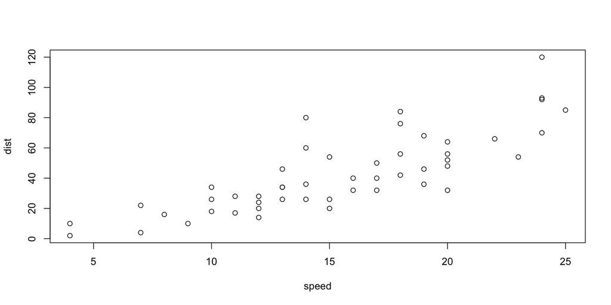

```r
plot(cars)
```

## Le *knitting*

Une fois votre analyse terminée, cliquez sur le bouton `Knit` / `Render` en haut de l’éditeur Source pour produire un document.

# Exercice

## Exercice

Dans le document R Markdown / Quarto que vous venez de créer :

- **Modifiez l’en-tête YAML** : ajoutez un titre, un auteur ou une autrice et une date.
- **Écrivez un peu de texte**, p. ex. un titre et une courte phrase.
- **Insérez un chunk** :
  - Ajoutez quelques commandes simples, p. ex. calculez `5 + 5` et `30 / 6`.
  - Exécutez le chunk avec le **bouton play** ou le raccourci.
- Enregistrez le fichier à un endroit pratique, puis faites-en le rendu avec *Knit* / *Render*.